# SI_618_Day_04_Stats_and_Visualization_Inclass

### 📝 **Pie Charts** 🥧

There are many **issues** with pie charts, and the one below is a good example of what **not to do**. However, it's still common for people to want to create them. So, let's go over how to make a pie chart.

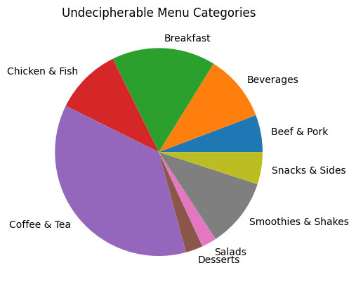

```python
# don't do this...
categories.plot(kind='pie', title='Undecipherable Menu Categories')
```

### 📝 **Challenge**:

What type of plot can **always** replace a pie chart? 🤔

Hint: Think about plots that show proportional relationships in a clearer and more accurate way.

## Answer: Bar Chart

In addition to the way we used **subplots** earlier in this class, we can use the **`.subplots()`** function to generate **multiple plots** within a figure. The **`.subplots()`** function returns a set of axes on which we can make plots.

To demonstrate how this works, let's start by filling in just one of the subplots:

## 📌 Subplots (again)

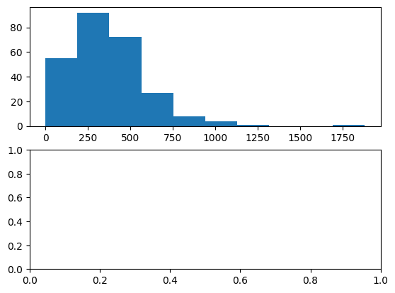

```python
f, (ax1, ax2) = plt.subplots(2)  # if only 1 argument, we assume it's the number of rows
ax1.hist(menu['Calories'])
plt.show()
```

Now let's fill in both subplots:

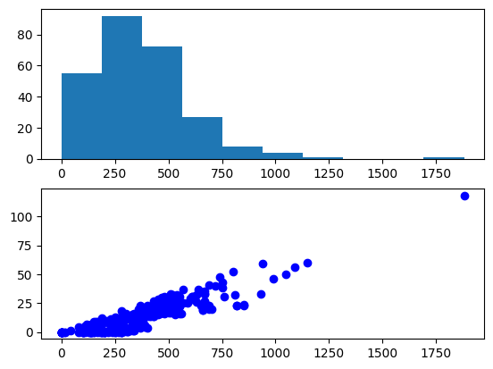

```python
f, (ax1, ax2) = plt.subplots(2)
ax1.hist(menu['Calories'])
ax2.plot(menu['Calories'], menu['Total Fat'], 'bo')
plt.show()
```

Now let's make a **2x2 layout** of 4 plots. 🖼️  
Note the structure of the return values from the **`.subplots()`** function: it returns a **2x2 array of axes**. Each subplot can be accessed using **`axes[row, col]`**.

This layout allows us to organize multiple plots in a single figure, making comparisons easier and more visually structured.

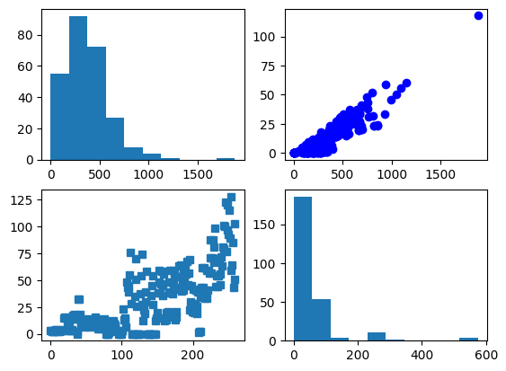

```python
f, ((ax1, ax2), (ax3, ax4)) = plt.subplots(2, 2)
ax1.hist(menu['Calories'])
ax2.plot(menu['Calories'], menu['Total Fat'], 'bo')
ax3.plot(menu['Sugars'], 's')
ax4.hist(menu['Cholesterol'])
plt.show()
```

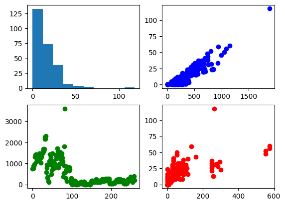

```python
f, ((ax1, ax2), (ax3, ax4)) = plt.subplots(2, 2)
ax1.hist(menu['Total Fat'])
ax2.plot(menu['Calories'], menu['Total Fat'], 'bo')
ax3.plot(menu['Sodium'], 'go')
ax4.plot(menu['Cholesterol'], menu['Total Fat'], 'ro')
plt.show()
```

Alternatively, we can use the **Pandas-Matplotlib integration** for plotting.  
Note the use of the **`ax=`** keyword argument, which allows you to specify the axes where the plot should appear within a subplot layout.

This makes it easy to generate multiple plots in different subplots while working directly with Pandas data structures.

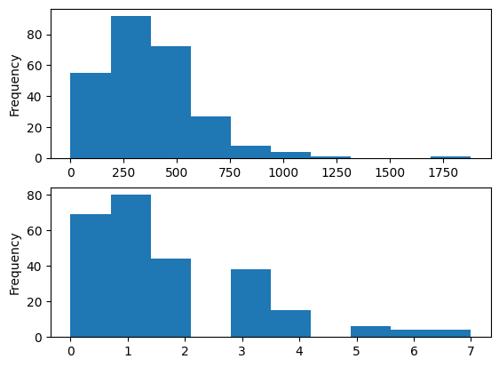

```python
f, (ax1, ax2) = plt.subplots(2)
menu['Calories'].plot(ax=ax1, kind='hist')
menu['Dietary Fiber'].plot(ax=ax2, kind='hist')
plt.show()
```

### 📝 **Challenge**:

Use **`subplots()`** to create a figure with **4 plots**.

You can choose from **scatter plots**, **histograms**, **bar charts**, **pie plots**, or any of the following types:

- `'line'` : line plot (default)
- `'bar'` : vertical bar plot
- `'barh'` : horizontal bar plot
- `'hist'` : histogram
- `'box'` : boxplot
- `'kde'` : Kernel Density Estimation plot
- `'density'` : same as `'kde'`
- `'area'` : area plot
- `'pie'` : pie plot

Try experimenting with different plot types in each subplot and create a diverse figure!

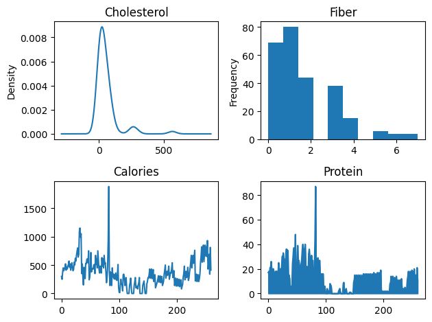

```python
f, ((ax1, ax2), (ax3, ax4)) = plt.subplots(2, 2)
menu['Cholesterol'].plot(ax=ax1, kind='kde', title = 'Cholesterol')
menu['Dietary Fiber'].plot(ax=ax2, kind='hist', title = 'Fiber')
menu['Calories'].plot(ax=ax3, kind='line', title = 'Calories')
menu['Protein'].plot(ax=ax4, kind='area', title = 'Protein')
# increase width between plots
plt.tight_layout() # increases width between plots despite the name
plt.show()
```

# 🌟 **BREAK**

Take a moment to stretch and recharge! 💪☕

## 📌 Simple (univariate) statistics

```python
# The weights of a herd of 80 cows
# Fixing random state for reproducibility
np.random.seed(618)

measures = (np.random.standard_normal(80)*150+1000).astype(int)
measures
```

```
array([1167, 1075,  893, 1066, 1025, 1084,  665, 1021, 1085,  886, 1161,
        959, 1008, 1004,  953, 1050, 1091,  857,  881,  891, 1048, 1213,
       1094, 1031,  935, 1014, 1054,  933, 1053, 1026,  844,  996, 1115,
        836,  884,  901,  801, 1226, 1091, 1448, 1119, 1215, 1199, 1030,
       1163,  987,  925, 1127, 1108, 1146, 1400,  984, 1035,  841, 1015,
        922, 1042, 1026,  888,  987,  933,  850, 1237, 1018,  955, 1308,
        817, 1146, 1022,  884, 1200,  979,  787, 1056, 1105, 1101, 1054,
       1285,  770,  710])
```

```python
# equivalently
# Fixing random state for reproducibility
np.random.seed(618)

measures = (np.random.normal(1000,150,80)).astype(int)
measures
```

```
array([1167, 1075,  893, 1066, 1025, 1084,  665, 1021, 1085,  886, 1161,
        959, 1008, 1004,  953, 1050, 1091,  857,  881,  891, 1048, 1213,
       1094, 1031,  935, 1014, 1054,  933, 1053, 1026,  844,  996, 1115,
        836,  884,  901,  801, 1226, 1091, 1448, 1119, 1215, 1199, 1030,
       1163,  987,  925, 1127, 1108, 1146, 1400,  984, 1035,  841, 1015,
        922, 1042, 1026,  888,  987,  933,  850, 1237, 1018,  955, 1308,
        817, 1146, 1022,  884, 1200,  979,  787, 1056, 1105, 1101, 1054,
       1285,  770,  710])
```

### 📝 Exercise 9:

Calculate some summary statistics for the `measures` variable you just created.

```python
mean = np.mean(measures)
median = np.median(measures)
std_dev = np.std(measures)
minimum = np.min(measures)
maximum = np.max(measures)
```

## 📌 **Visualizing Data with Seaborn** 🎨

- **Seaborn** is a visualization package built on top of **Matplotlib**.
- It’s designed to **make your life easier** when creating complex visualizations.
- Seaborn plays well with **Pandas**, **NumPy**, **SciPy**, and **Statsmodels**.
- It includes many different visualizations, such as:
  - **Strip plots**, **Swarm plots**
  - **Box plots**
  - **Histograms**

To get started, we need to import the package (typically imported as `sns`):

```
import seaborn as sns
```

## 📌 **Seaborn versus Matplotlib** 🎨

### **Matplotlib**:

- 🔧 **Low-level**: The foundation for many visualization packages.
- 😖 Can be **painful** to construct certain graphs.
- 🐼 **Not Pandas-friendly**.
- 🖱️ **Not interactive**.

### **Seaborn**:

- 🐼 **Pandas-friendly**: Works seamlessly with DataFrames.
- 📊 Great for **statistical plots** like box plots, violin plots, and more.

Each has its strengths, so use them based on your needs!

```python
import seaborn as sns
```

## 📌 Strip Plot

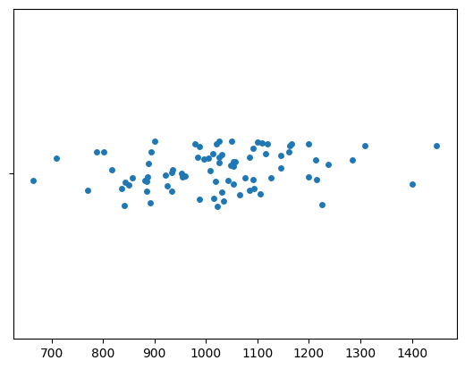

```python
sns.stripplot(x=measures)
```

## 📌 Swarm Plot

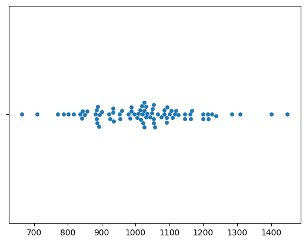

```python
sns.swarmplot(x=measures)
```

## 📌 Box Plot

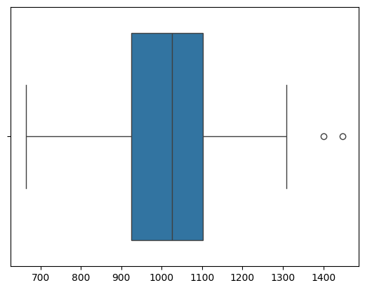

```python
sns.boxplot(x=measures)
```

And we can manipulate the **underlying plot** to control different features. For more details, check out these resources:

🔗 [Why do many examples use `fig, ax = plt.subplots()` in Matplotlib? (Stack Overflow)](https://stackoverflow.com/questions/34162443/why-do-many-examples-use-fig-ax-plt-subplots-in-matplotlib-pyplot-python#34162641)  
🔗 [Matplotlib `plt.subplots()` Documentation](https://matplotlib.org/api/pyplot_api.html#matplotlib.pyplot.subplots)

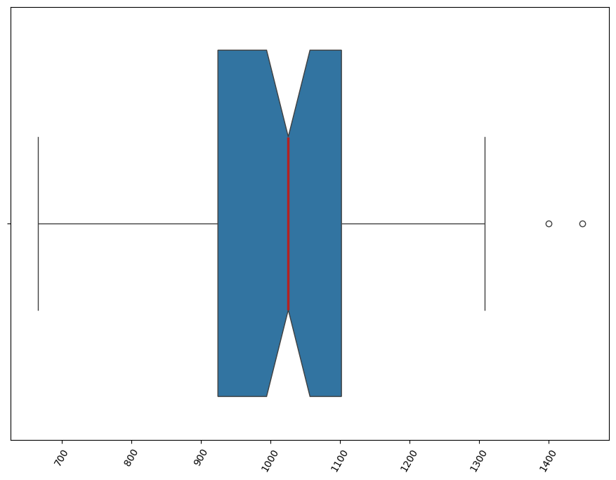

```python
fig, ax = plt.subplots()
fig.set_size_inches(11, 8)
medianprops = dict(linewidth=2.5, color='firebrick')
sns.boxplot(medianprops=medianprops, data=measures, orient='h', notch=True)
_ = plt.xticks(rotation=60)
```

## 📌 **Histogram** 📊

We’re going to use this a lot! Seaborn adds a nice **smooth line** over the distribution. Think of this line as an **extrapolation**: if we had a lot more data, the distribution would eventually smooth out into something that resembles the line.

We’ll talk more about this soon, but for now, just keep in mind that it represents a smoothed version of your data’s distribution.

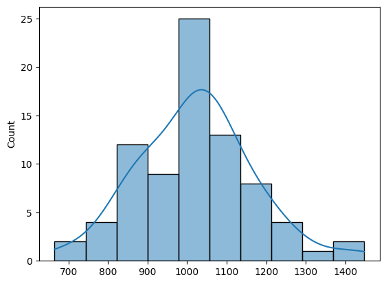

```python
# x axis = value, y axis = count (frequency)
sns.histplot(measures, kde=True)
```

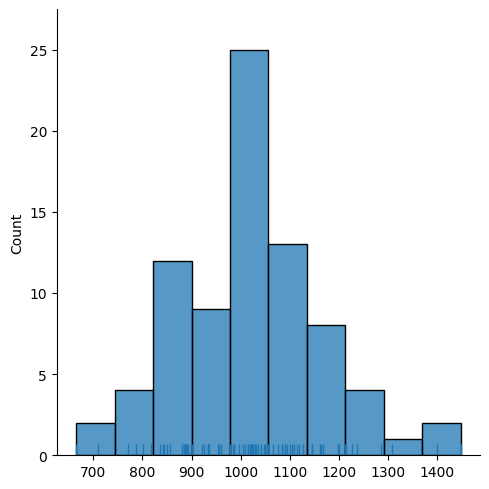

```python
# note use of displot rather than histplot
sns.displot(measures, rug=True); # show a strip plot on bottom -- we call it a "rug"
```

📌 ## Visualizing the menu data using Seaborn

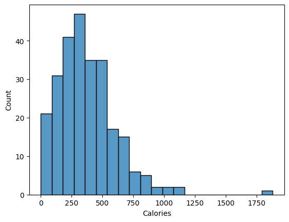

```python
sns.histplot(menu.Calories)
```

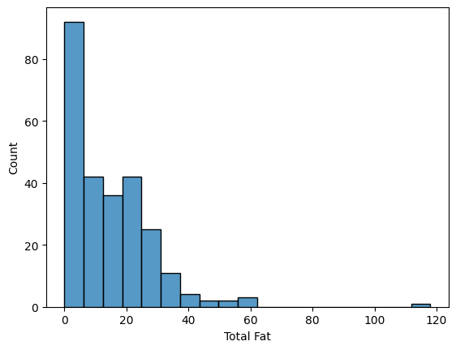

```python
sns.histplot(menu['Total Fat'])
```

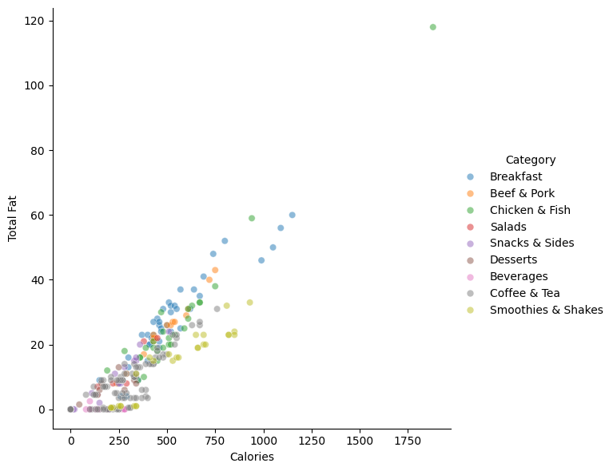

```python
sns.relplot(x="Calories", y="Total Fat", hue="Category",
            sizes=(40, 400), alpha=.5,
            height=6, data=menu)
```

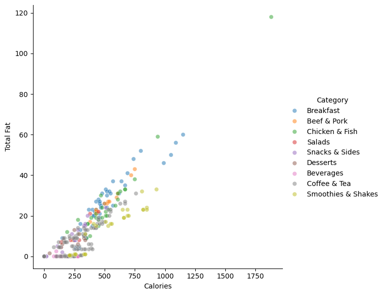

```python
# Relationship between petal_width & petal_length by species
sns.relplot(x="Calories", y="Total Fat",hue="Category",
            sizes=(40, 400), alpha=.5,
            height=6, data=menu)
```

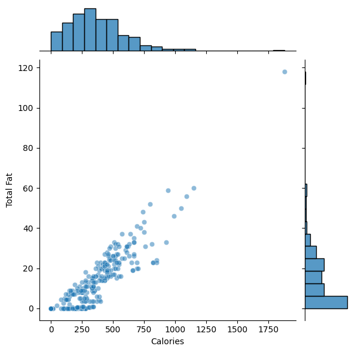

```python
sns.jointplot(x='Calories', y='Total Fat', data=menu, alpha=.5)
```

It can sometimes be difficult to see where the **interesting areas** in the plot are. In such cases, it’s worth trying a **hexbin plot**.

Go ahead and copy the above code block, and add `kind="hex"` to the **`jointplot()`** parameters to visualize the density of data points more effectively.

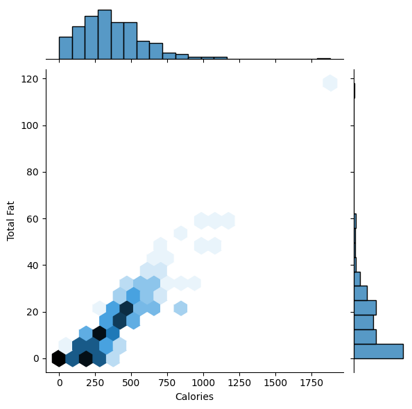

```python
sns.jointplot(x='Calories', y='Total Fat', data=menu, kind="hex")
```

Finally, you may want to look at all the **numeric variables** in your dataset.  
To do this, use **`pairplot`**:

```
sns.pairplot(your_dataframe)
```

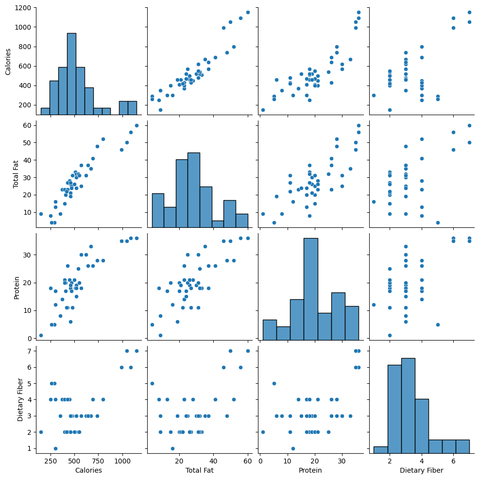

```python
sns.pairplot(menu.query("Category == 'Breakfast'"),
             vars=['Calories', 'Total Fat', 'Protein', 'Dietary Fiber'])
```

We can get **fancier** by using a different column to set the **color** (or "hue") in our plot.

Try running the following code:

```
sns.pairplot(your_dataframe, hue='your_column')
```

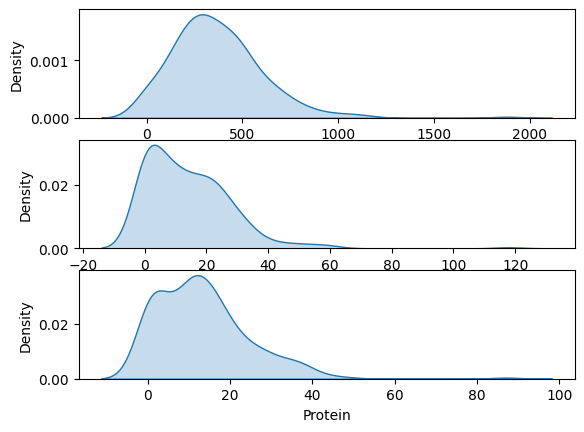

```python
f, ax = plt.subplots(3)
for i,varname in enumerate(['Calories','Total Fat','Protein']):
    sns.kdeplot(menu[varname], ax=ax[i], shade=True)
```

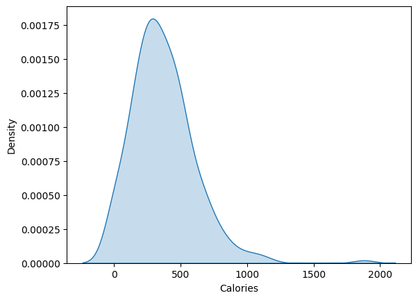

```python
sns.kdeplot(data=menu['Calories'], shade=True)
```

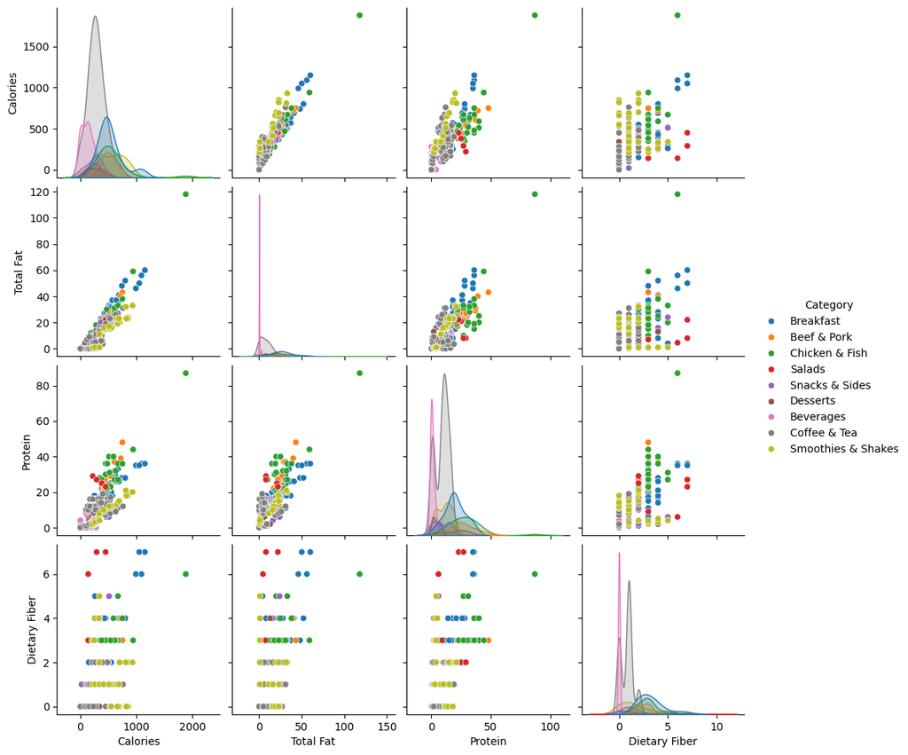

```python
sns.pairplot(data=menu,
             hue="Category",
             vars=['Calories', 'Total Fat', 'Protein', 'Dietary Fiber'])
```

## 📌 **Why Do We Care About Distributions?** 📊

Understanding **distributions** helps us recognize patterns in our data and make informed decisions based on how values are spread out.

## 📌 **The World is Not Normal** 🌍

- There are **many different kinds of distributions**, not just the normal (Gaussian) distribution.
- By **examining the distribution**, we can infer the underlying structure of the data and identify what type of distribution we’re working with.

## 📌 Uniform

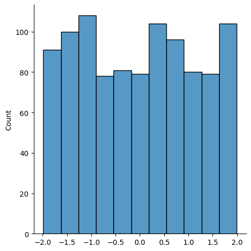

```python
uniform = np.random.uniform(-2, 2, 1000)  # low,high,count
sns.displot(uniform, kde=False)
```

## 📌 Bimodal

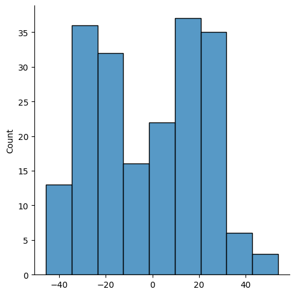

```python
bimodal = np.append(np.random.normal(-20, 10, 100),
                    np.random.normal(20, 10, 100))
sns.displot(bimodal)
```

# 🌟 Poisson

$$ P(k~events~in~interval) = \frac{\lambda^ke^{-\lambda}}{k!} $$

$\lambda$ represents the **event rate** (i.e., the average number of occurrences in a given time period).

### **Examples**:

- 🌠 **Meteor strikes**
- 🏥 **Arrival of patients** to a hospital

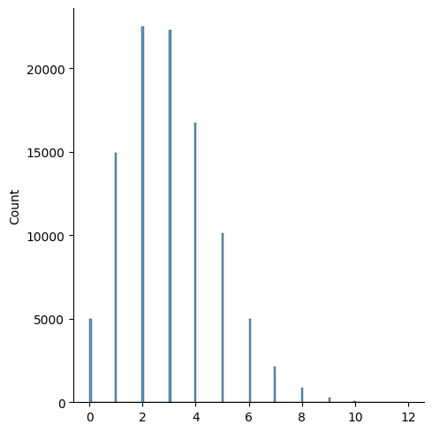

```python
# as lambda goes up --> looks more normal
pois = np.random.poisson(3, 100000) # lambda, count
sns.displot(pois)
```

# 🌟 **Power/Zipf/Pareto Distributions**

The general formula for these distributions is:

$$ P = \frac{x^{-a}}{\zeta(a)} $$

### **Characteristics of "long tail" distributions**:

- **Degree distribution** (e.g., in networks)
- **Movie/music popularity** (e.g., a few hits, many less popular items)
- **Words** (e.g., common vs. rare words in a language)

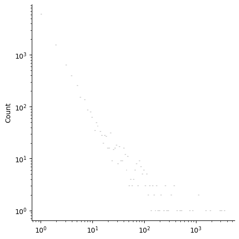

```python
power = np.random.zipf(2, 10000)
sns.displot(power, log_scale=(True, True))
```

## 📌 Visual Tests on Data

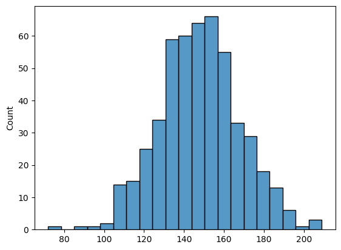

```python
testdata = (np.random.standard_normal(500)*20+150).astype(int)
sns.histplot(testdata)
```

## 📌 **Run Sequence** 📈

- A **Run Sequence** plot shows **index versus value**.
- If the plot is **flat** and **non-drifting**:
  - The **fixed-location assumption** holds.
- If the **vertical spread** is consistent across the entire plot:
  - The **fixed-variation assumption** holds.

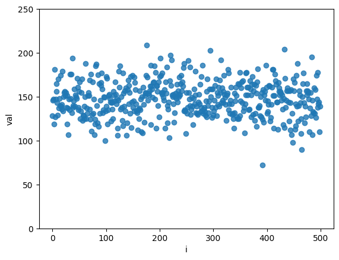

```python
ax = sns.regplot(x=np.arange(len(testdata)), y=testdata, fit_reg=False)
ax.set_ylim(0, 250)
ax.set_ylabel("val")
ax.set_xlabel("i")
```

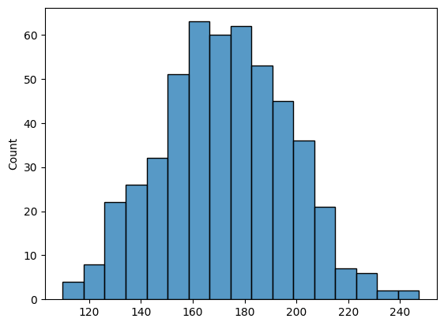

```python
drifting = np.array([testdata[i]+i*(.1) for i in np.arange(len(testdata))])
sns.histplot(data=drifting, kde=False)
```

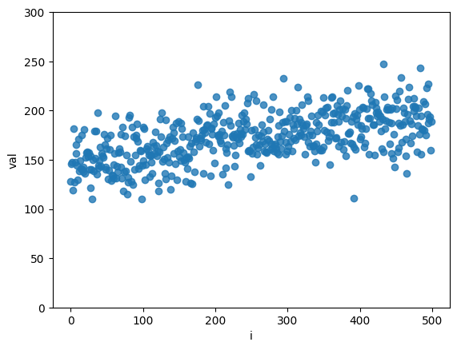

```python
ax = sns.regplot(x=np.arange(len(drifting)), y=drifting, fit_reg=False)
ax.set_ylim(0, 300)
ax.set_ylabel("val")
ax.set_xlabel("i")
```

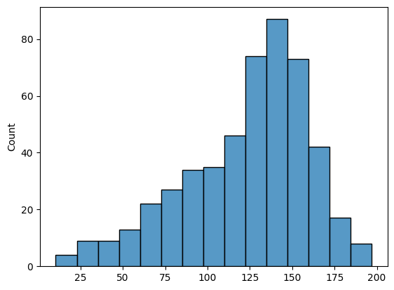

```python
expanding = np.array([(testdata[i]+i*np.random.randint(-1,1)*.2)
                     for i in np.arange(len(testdata))])
sns.histplot(expanding)
```

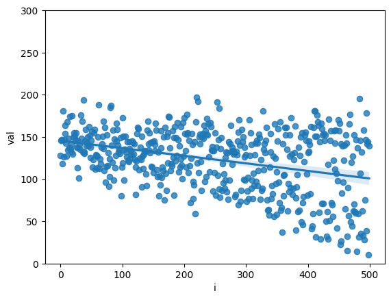

```python
ax = sns.regplot(x=np.arange(len(expanding)), y=expanding)
ax.set_ylim(0, 300)
ax.set_ylabel("val")
ax.set_xlabel("i")
```

# 🌟 **Lag Plot** 📊

- Plot point $y_i$ versus $y_{i-1}$.
- If the **lag plot** is **structureless**:
  - The **randomness assumption** holds.

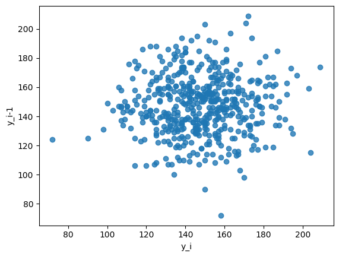

```python
lag = testdata.copy()
lag = np.array(lag[:-1])
current = testdata[1:]
ax = sns.regplot(x=current, y=lag, fit_reg=False)
ax.set_ylabel("y_i-1")
ax.set_xlabel("y_i")
```

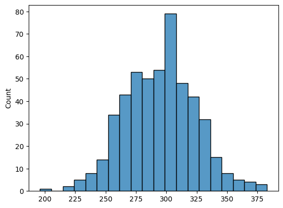

```python
connected = np.array([testdata[i]+testdata[i-1] for i in np.arange(500)])
sns.histplot(connected)
```

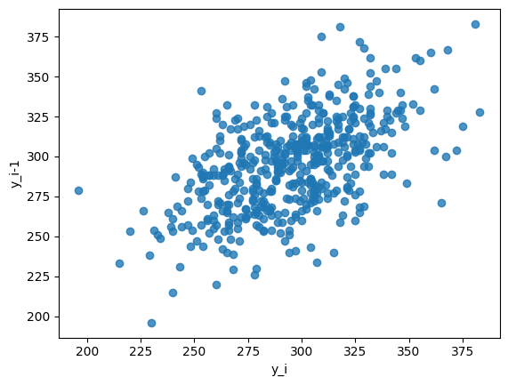

```python
lag = connected.copy()
lag = np.array(lag[:-1])
current = connected[1:]
ax = sns.regplot(x=current, y=lag, fit_reg=False)
ax.set_ylabel("y_i-1")
ax.set_xlabel("y_i")
```

## 📌 **QQ Plot** 📈

- A **QQ Plot** takes our **n ordered data points**:
  - Sorted from smallest to largest.
- It asks:
  - What is the relationship between **quantiles from our data** and **quantiles from a theoretical distribution** that we're assuming the sample is drawn from?

```python
from scipy import stats
```

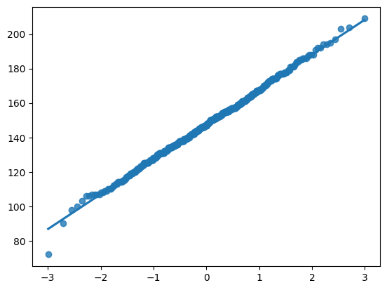

```python
qntls, xr = stats.probplot(testdata, fit=False)
sns.regplot(y=xr, x=qntls)
```

Another way to do exactly the same thing:

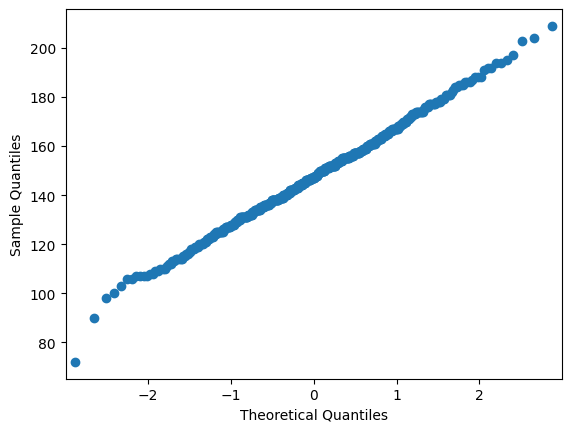

```python
import statsmodels.api as sm

sm.qqplot(testdata)
plt.show()
```

```python
def random_snorm(n, mean = 0, sd = 1, xi = 1.5):
    def random_snorm_aux(n, xi):
        weight = xi/(xi + 1/xi)
        z = np.random.uniform(-weight,1-weight,n)
        xi_ = xi**np.sign(z)
        random = -np.absolute(np.random.normal(0,1,n))/xi_ * np.sign(z)
        m1 = 2/np.sqrt(2 * np.pi)
        mu = m1 * (xi - 1/xi)
        sigma = np.sqrt((1 - m1**2) * (xi**2 + 1/xi**2) + 2 * m1**2 - 1)
        return (random - mu)/sigma

    return random_snorm_aux(n, xi) * sd + mean
```

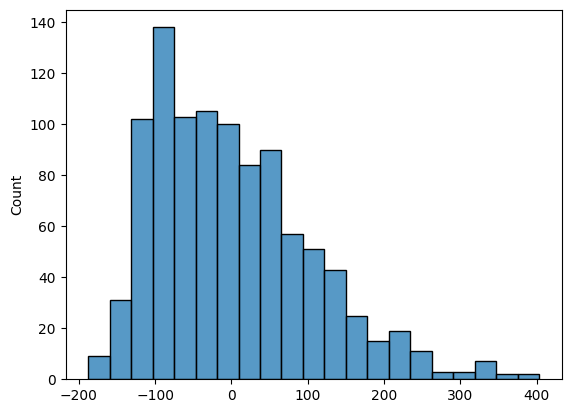

```python
rightskewed = random_snorm(1000, xi=2)*100
sns.histplot(rightskewed, kde=False)
```

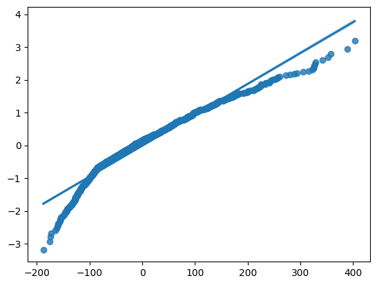

```python
qntls, xr = stats.probplot(rightskewed, fit=False)
sns.regplot(x=xr, y=qntls)
```

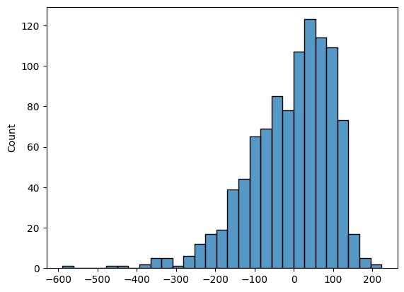

```python
leftskewed = random_snorm(1000, xi=-2)*100
sns.histplot(leftskewed, kde=False)
```

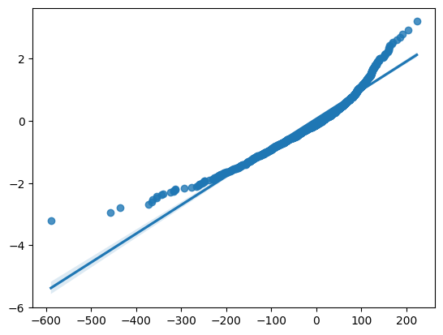

```python
qntls, xr = stats.probplot(leftskewed, fit=False)
sns.regplot(x=xr, y=qntls)
```

## 📌 **Now for the serious plots...** 🎨

Let's wrap them in a **single function** that we can call repeatedly to generate the plots efficiently.

By doing this, we avoid repeating code and make our plotting process smoother and more modular.

```python
import matplotlib.pyplot as plt
import seaborn as sns
from scipy import stats
```

```python
def multiplePlots(series):

    fig, axs = plt.subplots(2, 2)
    plt.tight_layout(pad=0.4, w_pad=4, h_pad=1.0)

    # Histogram
    sns.histplot(series, ax=axs[0, 0])

    # Lag plot
    lag = series.copy()
    lag = np.array(lag[:-1])
    current = series[1:]
    ax = sns.regplot(x=current, y=lag, fit_reg=False, ax=axs[0, 1])
    ax.set_ylabel("y_i-1")
    ax.set_xlabel("y_i")

    # QQ plot (updated 2023.08.18.1.CT to match usual QQ plot -- axes flipped)
    qntls, xr = stats.probplot(series, fit=False)
    sns.regplot(y=xr, x=qntls, ax=axs[1, 0])

    # Run sequence
    ax = sns.regplot(x=np.arange(len(series)), y=series, ax=axs[1, 1])
    ax.set_ylabel("val")
    ax.set_xlabel("i")
```

## 📌 Now run this on `measures`

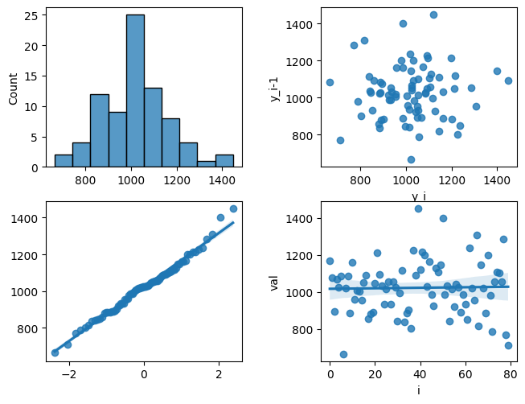

```python
multiplePlots(measures)
```

### 📝 **Challenge**:

The `sample.csv` file, loaded for you in the next cell, contains **9 variables** (`v0` through `v8`) that represent measures drawn from different distributions.  
Your task is to use the **investigative techniques** we discussed in today's lab to determine the type of distribution each variable is drawn from.

Start by loading the CSV file into a **DataFrame**, then analyze various aspects of **each** variable.

### **Your responses should include both code and markdown cells**, with markdown statements like:

> Variable `v99` appears to be drawn from a **uniform distribution** with a mean of **X** and standard deviation of **Y**.  
> A histogram of the data shows...  
> The QQ plot reveals...

### **Note**:

- Avoid repeating your code. Use **loops**, **functions**, or other techniques to keep your code **DRY** ([Don't Repeat Yourself](https://en.wikipedia.org/wiki/Don%27t_repeat_yourself)).

```python
distributions = pd.read_csv('https://raw.githubusercontent.com/umsi-data-science/data/main/sample.csv',index_col=0)
```

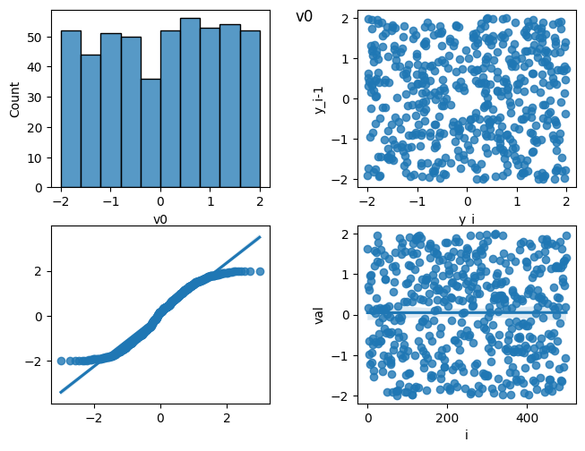

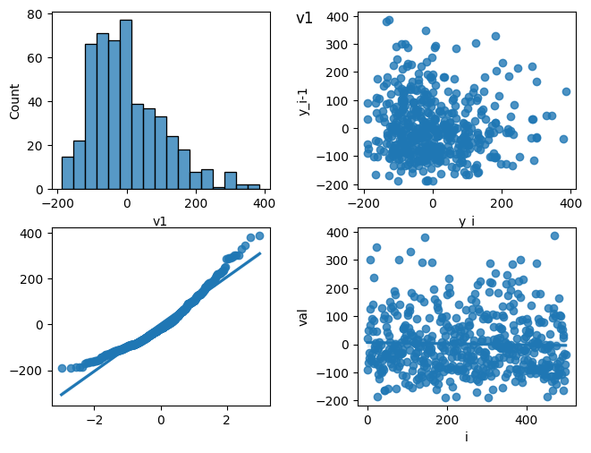

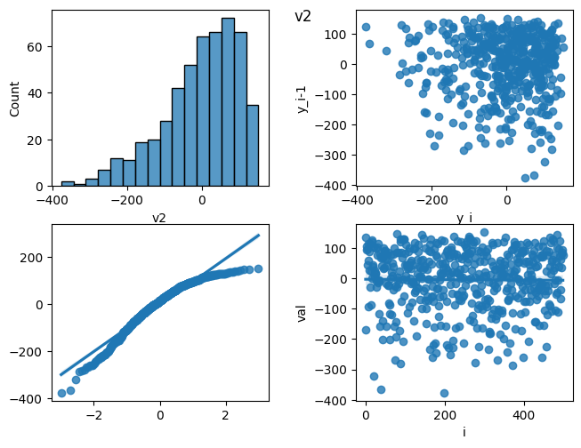

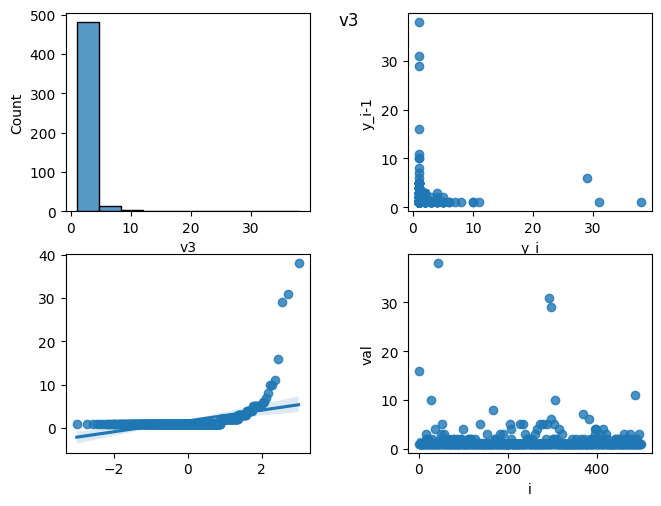

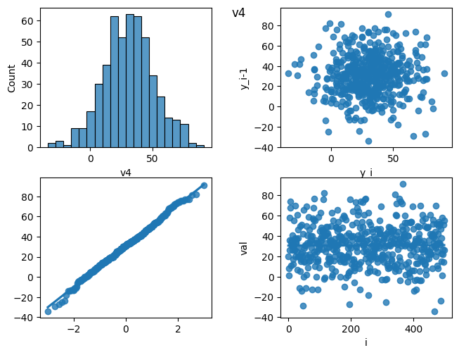

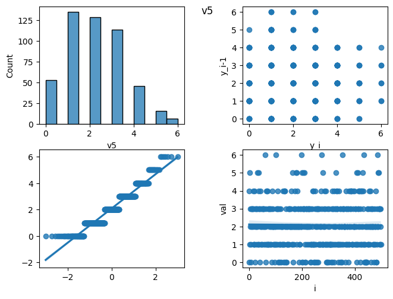

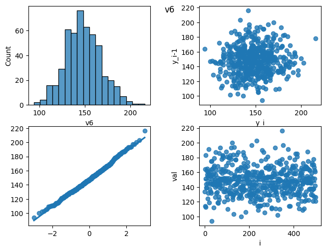

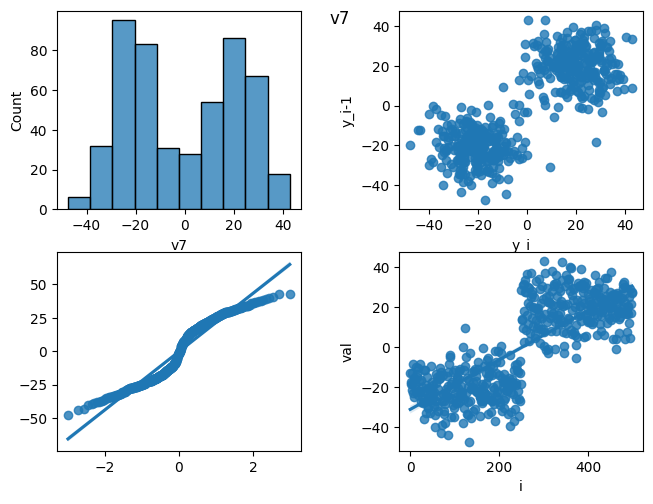

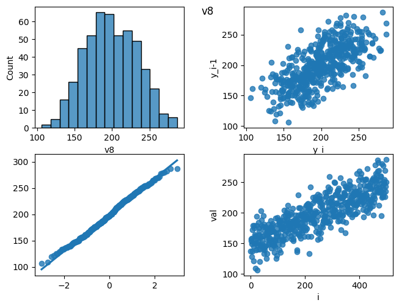

```python
# distributions.describe()

for col in distributions.columns:
    multiplePlots(distributions[col])
    plt.suptitle(col)
    plt.show()
```

## V0

V0 looks to be distributed close to uniformly between -2 and 2. There is no apparent lagged relationship.

## V2

The V2 variable has a long left tail. The distribution shows a negative skew.

## V3

This variable shows a steep right skew, implying large outliers above the mode.

## V6

V6 is normally distributed.

## V7

The histogram for V7 implies a bimodal distribution. This is reflected in both the lag plot and the sequence plot, which have two distinct concentrations of observations.

## V8

V8 is normally distributed. The lag plot carries a positive trend, implying that there is a correlation between the current and prior values.

```python
# distributions['v2'].hist()
```

## 🏁 **END OF NOTEBOOK**

### 📥 **Remember to submit** this file in **HTML** and **IPYNB** formats via Canvas.